# OPI Forecasts

Thomas Buehrens, WDFW (tbuehrens@dfw.wa.gov), Mark Sorel, WDFW (mark.sorel@dfw.wa.gov), Cassandraw Leeman, ODFW (cassandra.r.leeman@odfw.oregon.gov), and Shannon Conley, WDFW (shannon.conley@dfw.wa.gov)

Last Updated 09/09/2023.

# Overview

```r
options(width = 100)
knitr::opts_chunk$set(message = FALSE)
set.seed(123)
```

```r
wd_functions<-"functions"
sapply(FUN = source, paste(wd_functions, list.files(wd_functions), sep="/"))
```

```r
packages_list<-c("tidyverse"
                 ,"forecast"
                 ,"mgcv"
                 ,"ggplot2"
                 ,"MASS"
                 ,"RColorBrewer"
                 ,"kableExtra"
                 ,"modelr"
                 ,"kableExtra"
                 ,"reshape2"
                 ,"ggfortify"
                 ,"clock"
                 ,"smooth"
                 ,"scales"
                 ,"gtools"
                 ,"CombMSC"
                 ,"here"
                 ,"MuMIn"
                 ,"janitor"
                 ,"rvest"
                 ,"lubridate"
                 ,"rnoaa"
                 ,"ncdf4"
                 ,"magrittr"
                 ,"ggcorrplot"
                 )
install_or_load_pack(pack = packages_list)
```

## User Inputs

This section contains parameters input to control the forecasting process

```r
#=========
# Raw Data
#=========
yr_start<-2000
yr_end<-year(Sys.Date())
#dam="BON"
species="Coho"
#===========================
# Summarization for analysis
#===========================
date_start_analysis<-ymd("2000/1/1") #this will be the first date of data used in the analysis (and this month/day first in years thereafter)
date_end_analysis<-ymd("2023/12/31") #this will be the last date of data used in the analysis (and this month/day last in years preceding)
forecast_period_start_m<-1 #this will be the month associated with the first month/day of the seasonal estimate period each year...can be after first data used to estimate it or the same
forecast_period_start_d<-1 #this will be the month day associated with the first month/day of the seasonal estimate period each year...can be after first data used to estimate it or the same
last_data<-Sys.Date()
#==================
#forecasting params
#==================
leave_yrs<- 16
TY_ensemble<-11
k<-1
covariates<-c(#new
              "lag1_log_JackOPI"
              ,"lag1_log_SmAdj"
              ,"lag1_NPGO"
              ,"lag1_PDO"
              ,"WSST_A"

              #OCN
              ,"PDO.MJJ"
              ,"MEI.OND"
              ,"UWI.JAS"
              ,"SST.AMJ"
              ,"SSH.AMJ"
              ,"UWI.SON"

              #Very correlated with variables already included
              #,"lag1_fall_Nino3.4"
              #,"SST.J"

              #Original OPIT indicators very correlated with variables already used(but untransformed)
              #"lag1_JackOPI"
              #,"lag1_SmAdj"

              #NOAA Ocean Indicators
              #,"lag1_sp_phys_trans"
              #,"lag1_PC1"
              )
plot_results = F
first_forecast_period = 1
write_model_summaries = TRUE
find_best=T
#==============
#Ensemble Params
#===============
min_vars<-0
max_vars<-5
forecast_type<-"preseason"
stack_metric<-"MAPE"
num_models<-40

inputs<-list(
  yr_start = yr_start,
  yr_end = yr_end,
  species = species,
  date_start_analysis = date_start_analysis,
  date_end_analysis = date_end_analysis,
  forecast_period_start_m = forecast_period_start_m,
  forecast_period_start_d = forecast_period_start_d,
  last_data = last_data,
  leave_yrs = leave_yrs,
  TY_ensemble = TY_ensemble,
  k = k,
  covariates = covariates,
  plot_results = plot_results,
  first_forecast_period = first_forecast_period,
  write_model_summaries = write_model_summaries,
  find_best = find_best,
  min_vars = min_vars,
  max_vars = max_vars,
  forecast_type = forecast_type,
  stack_metric = stack_metric,
  num_models = num_models
)

print(inputs)
```

```
## $yr_start
## [1] 2000
##
## $yr_end
## [1] 2023
##
## $species
## [1] "Coho"
##
## $date_start_analysis
## [1] "2000-01-01"
##
## $date_end_analysis
## [1] "2023-12-31"
##
## $forecast_period_start_m
## [1] 1
##
## $forecast_period_start_d
## [1] 1
##
## $last_data
## [1] "2023-09-09"
##
## $leave_yrs
## [1] 16
##
## $TY_ensemble
## [1] 11
##
## $k
## [1] 1
##
## $covariates
##  [1] "lag1_log_JackOPI" "lag1_log_SmAdj"   "lag1_NPGO"        "lag1_PDO"         "WSST_A"
##  [6] "PDO.MJJ"          "MEI.OND"          "UWI.JAS"          "SST.AMJ"          "SSH.AMJ"
## [11] "UWI.SON"
##
## $plot_results
## [1] FALSE
```

[output cut: 9 more lines]

```
##
## $min_vars
## [1] 0
##
## $max_vars
## [1] 5
##
## $forecast_type
## [1] "preseason"
##
## $stack_metric
## [1] "MAPE"
##
## $num_models
## [1] 40
```

## Get Raw Data

Here we load the response variable (observed OPI coho abundance) and covariates used in past forecasts from Erik Suring’s GitHub repository [**OPIH Evaluation**](https://github.com/ErikSuring/OPIH_Evaluation). The version of the response variable (observed OPI coho abundance) in Erik’s GitHub page differs from the official data set used by ODFW and WDFW, so consequently, we also load that official data set provided by Cassandra Leeman (ODFW) on 9/8/2023 and we use those numbers instead of those in Erik’s repository for years where they differ. Finally, we also load some auxiliary covariates including:

1. [Pacific Decadal Oscillation](https://www.ncei.noaa.gov/access/monitoring/pdo/)
2. [North Pacific Gyre Oscillation](http://www.o3d.org/npgo/)
3. [NOAA Ocean Indicators](https://www.fisheries.noaa.gov/west-coast/science-data/ocean-ecosystem-indicators-pacific-salmon-marine-survival-northern)
4. [NOAA NOAA Extended Reconstructed SST version 5](https://psl.noaa.gov/data/gridded/data.noaa.ersst.v5.html)
5. [NOAA Oceanic Nino 3.4 Index (lag 1 Oct-December mean)](https://psl.noaa.gov/gcos_wgsp/Timeseries/Nino34/)

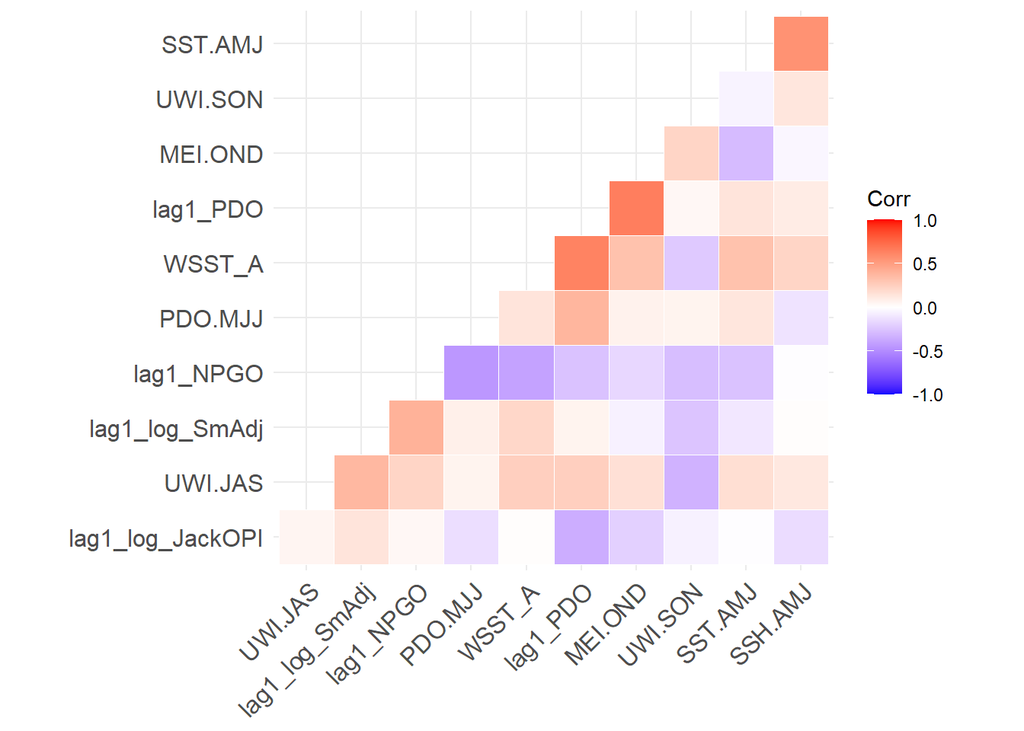

```r
OPIHData <- read.table("https://raw.githubusercontent.com/ErikSuring/OPIH_Evaluation/main/PUB2023.txt", header = TRUE, sep = "\t", strip.white = TRUE, comment.char = "#")

nYears <- length(OPIHData[,1])
earliestYear <- OPIHData[1,1]
latestYear <- OPIHData[nYears,1]

OPIHData$AdltAll <- c(OPIHData$AdltSRS[1:17],OPIHData$AdltMSM[18:nYears])   # row 18  <-  1986. Use SRS data prior, MSM data post
OPIHData$AdltAllno83 <- OPIHData$AdltAll
OPIHData$AdltAllno83[15] <-  NA   #  1983 is removed from model input data
OPIHData[,"AdltAll"] <- OPIHData$AdltAll
OPIHData[,"AdltAllno83"] <- OPIHData$AdltAllno83

# Lag Jack and Smolt data to return year
OPIHData[,"lagJackCR"] <- c(NA, OPIHData$JackCR[1:nYears-1])
OPIHData[,"lagJackOC"] <- c(NA, OPIHData$JackOC[1:nYears-1])
OPIHData[,"lagJackOPI"] <- OPIHData$lagJackCR + OPIHData$lagJackOC

OPIHData[,"lagSmD"] <- c(NA, OPIHData$SmD[1:nYears-1])
OPIHData[,"lagSmCR"] <- c(NA, OPIHData$SmCR[1:nYears-1])
OPIHData[,"lagSmAdj"] <- OPIHData$lagJackCR*(OPIHData$lagSmD/OPIHData$lagSmCR)   #  Calculate Smolt Adjustment

# Output OPIHData as a .csv file
#write.table(OPIHData, file = "OPIHData.csv", sep = ", ", row.names=FALSE)

OPIHData%<>%
  dplyr::rename(year=Year,
                abundance = AdltAllno83
                )%>%
  as_tibble()%>%
  arrange(year)

Yrlist<-data.frame(year=c(min(OPIHData$year):(max(OPIHData$year)+1)))

OPIHData%<>%
  right_join(Yrlist)%>%
  arrange(year)
#=========================================================
#get PDO data
#=========================================================
PDO<-read_table("https://psl.noaa.gov/pdo/data/pdo.timeseries.ersstv5.csv",skip=1,col_names=F,comment="#")%>%
  dplyr::rename(Date=X1,PDO=X2)%>%
  filter(!PDO < -99)%>%
  mutate(Date=as.Date(Date),Month=month(Date),Year=as.integer(year(Date)))%>%
  group_by(Year)%>%
  add_tally()%>%
  #filter(!Month>6)%>% #use only spring (Jan-June) NPGO
  #filter(!n < 12)%>% #use only complete years
  group_by(Year)%>%
  dplyr::rename(year=Year)%>%
  dplyr::summarise(PDO=mean(PDO))%>%
  mutate(lag1_PDO = lag(PDO,1))%>%
  right_join(Yrlist)%>%
  dplyr::select(year,lag1_PDO)%>%
  filter(!is.na(lag1_PDO))
#=========================================================
#get NPGO data
#=========================================================
NPGO<-read_table("http://www.o3d.org/npgo/npgo.php",skip=29,col_names=F,comment="#")%>%
  filter(!is.na(X2))%>%
  dplyr::rename(Year=X1,Month=X2,NPGO=X3)%>%
  mutate(Year=as.integer(as.numeric(Year)))%>%
  group_by(Year)%>%
  add_tally()%>%
  #filter(!Month>6)%>% #use only spring (Jan-June) NPGO
  #filter(!n < 12)%>% #use only complete years
  group_by(Year)%>%
  dplyr::summarise(NPGO=mean(NPGO))%>%
  dplyr::rename(year=Year)%>%
  mutate(lag1_NPGO = lag(NPGO))%>%
  right_join(Yrlist)%>%
  arrange(year)%>%
  dplyr::select(year,lag1_NPGO)%>%
  filter(!is.na(lag1_NPGO))
#=========================================================
#get NOAA indicator data, wrangle into usable format, plot
#=========================================================
indicators<-read_csv("https://www.fisheries.noaa.gov/s3//2022-12/OEI-spotlight-cvs-2022-NWFSC.csv",skip=1)%>%
  filter(!is.na(`Ecosystem Indicators`))%>%
  pivot_longer(names_to = "Year",
                cols=c(starts_with("1"),starts_with("2")),
                values_to = "value")%>%
  pivot_wider(names_from=`Ecosystem Indicators`,values_from=value)%>%
  mutate(year=as.integer(Year))%>%
  dplyr::select(-Year)%>%
  right_join(Yrlist)%>%
  arrange(year)%>%
  mutate(lag1_PC1 = lag(scale(`Principal Component scores (PC1)`)[,1]))%>%
  filter(!is.na(lag1_PC1))
#=========================================
# Get ENSO index
#=========================================
enso<-read_table("https://psl.noaa.gov/gcos_wgsp/Timeseries/Data/nino34.long.anom.data",skip=1,col_names = F)%>%
  as_tibble()%>%
  setNames(c("year",1:12))%>%
  filter(year%in%as.character(yr_start:yr_end))%>%
  mutate(across(everything(),~as.numeric(.)))%>%
  pivot_longer(names_to = "month",values_to = "Nino3.4",cols=c(!year))%>%
  filter(Nino3.4>-10 & Nino3.4 <10)%>%
  filter(month%in%c(10:12))%>%
  group_by(year)%>%
  summarise(fall_Nino3.4=mean(Nino3.4))%>%
  right_join(Yrlist)%>%
  mutate(lag1_fall_Nino3.4=lag(fall_Nino3.4))%>%
  dplyr::select(-fall_Nino3.4)

#===========================================================================================================
#Get ERSST data: get_ersst_v5_data takes A LONG TIME (1 hr) vs. get_ersst_v5_data_V2 which is much quicker!
#==========================================================================================================
sstdat<-get_ersst_v5_data_V2(years=c(min(Yrlist$year):max(Yrlist$year)),
                             data.dir="C:\\Users\\buehrtwb\\Washington State Executive Branch Agencies\\DFW-Team WDFW OPI Model Review - General" ,
                             ncfilename="sst.mnmean.nc",
                             latrange=c(44,50),
                             lonrange=c(-125,-120)
                             )

ssta<-sstdat%>%
  dplyr::select(year,month,resid)%>%
  mutate(month=as.numeric(month))%>%
  mutate(year=ifelse(month>9,year+1,year))%>%
  group_by(year)%>%
  summarise(WSST_A = mean(resid[month>9|month<2]),
            SSST_A = mean(resid[month<=9|month>=4]),
            )

#================
#Plot ERSST data
#================
# ggplot(sstdat,aes(x=factor(month),y=meanSST,group=year))+
#   geom_hline(yintercept=0,linetype="dashed")+
#   scale_color_brewer(palette = "Spectral")+
#   geom_line()+
#   facet_wrap(~factor(year))
#
# ggplot(sstdat,aes(x=factor(month),y=resid,group=year))+
#   geom_hline(yintercept=0,linetype="dashed")+
#   scale_color_brewer(palette = "Spectral")+
#   geom_line()+
#   facet_wrap(~factor(year))
#
# ggplot(sstdat,aes(x=factor(month),y=sstdiff,group=year))+
#   geom_hline(yintercept=0,linetype="dashed")+
#   scale_color_brewer(palette = "Spectral")+
#   geom_line()+
#   facet_wrap(~factor(year))
#==========================================
#Get OCN covariates
#==========================================
OCN<-read_csv("data/OCNR_Forecast_Summary.csv")%>%
  as_tibble()%>%
  dplyr::rename(year=YEAR)%>%
  dplyr::select(-c("ADULTS","SPAWNERS","Spawners"))
#================================================================
dat<-OPIHData%>%
  left_join(Yrlist)%>%
  left_join(PDO)%>%
  left_join(NPGO)%>%
  left_join(indicators)%>%
  left_join(enso)%>%
  left_join(ssta)%>%
  left_join(OCN)%>%
  dplyr::rename(lag1_JackOPI = lagJackOPI,
                lag1_SmAdj = lagSmAdj
                )%>%
  mutate(species = "Coho",
         period = 1,
         lag1_log_JackOPI = log(lag1_JackOPI),
         lag1_log_SmAdj = log(lagJackCR) * (lagSmD/lagSmCR),
         lag1_sp_phys_trans = lag(`Physical Spring Trans.\nUI based (day of year)`)
         )%>%
  ungroup()%>%
  dplyr::select(year,species,period,abundance,all_of(unique(unlist(covariates))))%>%
  filter(
    across(
      .cols = all_of(unique(unlist(covariates))),
      .fns = ~ !is.na(.x)
    )
  )%>%
  filter(year>=yr_start)#%>%mutate(across(!c(year,species,period,abundance),boxcox_scale(.)))

dat%>%
  dplyr::select(-c(year,species,period,abundance))%>%
  cor()%>%
  ggcorrplot(hc.order = TRUE, type = "lower", outline.col = "white", p.mat = NULL, sig.level = 0.05)
```

```r
dat%>%
  dplyr::select(-c(year,species,period,abundance))%>%
  cor()%>%
  round(.,2)
```

```
##                  lag1_log_JackOPI lag1_log_SmAdj lag1_NPGO lag1_PDO WSST_A PDO.MJJ MEI.OND UWI.JAS
## lag1_log_JackOPI             1.00           0.14      0.04    -0.35   0.01   -0.14   -0.20    0.05
## lag1_log_SmAdj               0.14           1.00      0.40     0.06   0.21    0.08   -0.06    0.37
## lag1_NPGO                    0.04           0.40      1.00    -0.26  -0.40   -0.45   -0.17    0.22
## lag1_PDO                    -0.35           0.06     -0.26     1.00   0.63    0.38    0.65    0.25
## WSST_A                       0.01           0.21     -0.40     0.63   1.00    0.14    0.32    0.25
## PDO.MJJ                     -0.14           0.08     -0.45     0.38   0.14    1.00    0.07    0.06
## MEI.OND                     -0.20          -0.06     -0.17     0.65   0.32    0.07    1.00    0.16
## UWI.JAS                      0.05           0.37      0.22     0.25   0.25    0.06    0.16    1.00
## SST.AMJ                     -0.01          -0.10     -0.26     0.14   0.32    0.13   -0.29    0.17
## SSH.AMJ                     -0.15           0.01     -0.01     0.10   0.22   -0.12   -0.04    0.12
## UWI.SON                     -0.06          -0.25     -0.28     0.04  -0.23    0.06    0.22   -0.33
##                  SST.AMJ SSH.AMJ UWI.SON
## lag1_log_JackOPI   -0.01   -0.15   -0.06
## lag1_log_SmAdj     -0.10    0.01   -0.25
## lag1_NPGO          -0.26   -0.01   -0.28
## lag1_PDO            0.14    0.10    0.04
## WSST_A              0.32    0.22   -0.23
## PDO.MJJ             0.13   -0.12    0.06
## MEI.OND            -0.29   -0.04    0.22
## UWI.JAS             0.17    0.12   -0.33
## SST.AMJ             1.00    0.56   -0.05
## SSH.AMJ             0.56    1.00    0.13
## UWI.SON            -0.05    0.13    1.00
```

## Analysis and summarization

This section shows the code used to analyze the data and summarize the results

```r
if(find_best ==T){
  best_covariates<-all_subsets(series=dat,covariates=covariates,min=min_vars,max=max_vars,type=forecast_type)
  saveRDS(best_covariates,"best_covariates_OPI_preseason.rds")
}

best_covariates<-readRDS("best_covariates_OPI_preseason.rds")

Table1<-best_covariates[[2]]%>%
  slice(1:num_models)%>%
  kbl(caption = "Table 1. Covariate Model Selection Results.",digits =3)%>%
  kable_classic(full_width = F, html_font = "Cambria")

results<-preseason_forecast_v3(series=dat,
                  leave_yrs=leave_yrs,
                  TY_ensemble=TY_ensemble,
                  covariates= best_covariates[[1]][best_covariates[[2]]$model_num[1:num_models]],
                  first_forecast_period = first_forecast_period,
                  plot_results = plot_results,
                  write_model_summaries = write_model_summaries,
                  forecast_period_start_m =  forecast_period_start_m, #inclusive
                  forecast_period_start_d =  forecast_period_start_d, #inclusive
                  stack_metric = stack_metric,
                  k=k
                  )

model_list<-lapply(best_covariates[[1]][best_covariates[[2]]$model_num[1:num_models]],function(x) paste(x,collapse = " + "))%>%
  unlist()%>%
  as_tibble()%>%
  add_rownames()%>%
  dplyr::rename(model=rowname,model_name=value)


results$forecast_skill%<>%
  left_join(model_list)%>%
  mutate(model_name=ifelse(is.na(model_name),model,model_name))%>%
  dplyr::select(!model)

Table2<-results$forecast_skill%>%
  kbl(caption = paste0("Table 2. One step ahead individual and ensemble model performance"),digits =2)%>%
  kable_classic(full_width = F, html_font = "Cambria")


results$forecasts%<>%
  left_join(model_list)%>%
  mutate(model_name=ifelse(is.na(model_name),model,model_name))%>%
  dplyr::select(!model)


Table3<-results$forecasts%>%
  filter(year==max(year))%>%
  dplyr::select(year,model_name,predicted_abundance,`Lo 50`,`Hi 50`,`Lo 95`,`Hi 95`,Stacking_weight)%>%
  kbl(caption = paste0("Table 3.Individual ensemble member predictions from the best ",num_models," models. These models were used to develop an ensemble using stacking weights which were optimized based on one-year-ahead performance over ",leave_yrs-1," years using ",stack_metric,". Optimized stacking weights are shown."),digits =2)%>%
  kable_classic(full_width = F, html_font = "Cambria")



best_model<-results$forecast_skill%>%
           filter(get(stack_metric) ==min(get(stack_metric)))%>%
           dplyr::select(model_name)%>%
           slice(1)%>%
           unlist()%>%pluck()

if(length(unique(results$forecasts$model_name))>1){
  results_best<-results$forecasts%>%
  ungroup()%>%
  filter(model_name == best_model
         )%>%
  dplyr::select(-period)
}


Table4<-results_best%>%
  dplyr::select(!c("train_test","Stacking_weight","model_name") & !c(covariates[covariates%in%names(results_best)]))%>%
  kbl(caption = paste0("Table 4. One-year-ahead forecasts of OPI ", species,". Additional covariates are included in the table below."),digits =2)%>%
  kable_classic(full_width = F, html_font = "Cambria")


Figure1<-ggplot(results_best,aes(x=year,y=predicted_abundance))+
  geom_ribbon(aes(ymin=`Lo 95`,ymax=`Hi 95`),color=NA,alpha=0.5,fill = "cadetblue")+
  geom_ribbon(aes(ymin=`Lo 50`,ymax=`Hi 50`),color=NA,alpha=0.5,fill = "cadetblue")+
  geom_line()+
  geom_point(aes(x=year,y=abundance))+
  ylim(0,NA)+
  scale_x_continuous(breaks=unique(results$forecasts$year))


Figure2<-ggplot(results$forecasts,aes(x=year,y=predicted_abundance,col=model_name))+
  geom_line()+
  geom_line(data=results_best,mapping=aes(x=year,y=predicted_abundance),size=1.5,col="black")+
  geom_point(aes(x=year,y=abundance),color="black")+
  ylim(0,NA)+
  scale_x_continuous(breaks=unique(results$forecasts$year))+
  theme(legend.position = "none")
  #theme(legend.key.size=unit(.15,'cm'),legend.position = "top")
```

## Results

Table 1 shows the model selection results sorted by AIC based on in-sample fits of ARIMA models tested on all subsets of covariates to the full (all years) data set. The ARIMA model structure for each covariate set was selected by the auto.arima function in the forecast package. These model selection results are generated as a first step to identify the top models for further use in evaluating out-of-sample one-step-ahead forecast skill, and constructing ensembles.

```r
Table1
```

Table 1. Covariate Model Selection Results.

| model_num | AICc | formula |
| --- | --- | --- |
| 84 | 12.615 | abundance ~ lag1_log_JackOPI + lag1_PDO + WSST_A |
| 268 | 13.087 | abundance ~ lag1_log_JackOPI + lag1_NPGO + lag1_PDO + WSST_A |
| 296 | 13.162 | abundance ~ lag1_log_JackOPI + lag1_PDO + WSST_A + PDO.MJJ |
| 702 | 15.262 | abundance ~ lag1_log_JackOPI + lag1_PDO + WSST_A + PDO.MJJ + MEI.OND |
| 300 | 15.584 | abundance ~ lag1_log_JackOPI + lag1_PDO + WSST_A + SSH.AMJ |
| 297 | 15.741 | abundance ~ lag1_log_JackOPI + lag1_PDO + WSST_A + MEI.OND |
| 240 | 15.792 | abundance ~ lag1_log_JackOPI + lag1_log_SmAdj + lag1_PDO + WSST_A |
| 714 | 15.838 | abundance ~ lag1_log_JackOPI + lag1_PDO + WSST_A + SST.AMJ + SSH.AMJ |
| 705 | 15.874 | abundance ~ lag1_log_JackOPI + lag1_PDO + WSST_A + PDO.MJJ + SSH.AMJ |
| 299 | 16.000 | abundance ~ lag1_log_JackOPI + lag1_PDO + WSST_A + SST.AMJ |
| 650 | 16.165 | abundance ~ lag1_log_JackOPI + lag1_NPGO + lag1_PDO + WSST_A + SSH.AMJ |
| 301 | 16.236 | abundance ~ lag1_log_JackOPI + lag1_PDO + WSST_A + UWI.SON |
| 646 | 16.252 | abundance ~ lag1_log_JackOPI + lag1_NPGO + lag1_PDO + WSST_A + PDO.MJJ |
| 298 | 16.334 | abundance ~ lag1_log_JackOPI + lag1_PDO + WSST_A + UWI.JAS |
| 590 | 16.498 | abundance ~ lag1_log_JackOPI + lag1_log_SmAdj + lag1_PDO + WSST_A + PDO.MJJ |
| 704 | 16.519 | abundance ~ lag1_log_JackOPI + lag1_PDO + WSST_A + PDO.MJJ + SST.AMJ |
| 649 | 16.614 | abundance ~ lag1_log_JackOPI + lag1_NPGO + lag1_PDO + WSST_A + SST.AMJ |
| 648 | 16.703 | abundance ~ lag1_log_JackOPI + lag1_NPGO + lag1_PDO + WSST_A + UWI.JAS |
| 647 | 16.844 | abundance ~ lag1_log_JackOPI + lag1_NPGO + lag1_PDO + WSST_A + MEI.OND |
| 651 | 17.145 | abundance ~ lag1_log_JackOPI + lag1_NPGO + lag1_PDO + WSST_A + UWI.SON |
| 562 | 17.258 | abundance ~ lag1_log_JackOPI + lag1_log_SmAdj + lag1_NPGO + lag1_PDO + WSST_A |
| 706 | 17.294 | abundance ~ lag1_log_JackOPI + lag1_PDO + WSST_A + PDO.MJJ + UWI.SON |
| 703 | 17.370 | abundance ~ lag1_log_JackOPI + lag1_PDO + WSST_A + PDO.MJJ + UWI.JAS |
| 709 | 19.036 | abundance ~ lag1_log_JackOPI + lag1_PDO + WSST_A + MEI.OND + SSH.AMJ |
| 594 | 19.294 | abundance ~ lag1_log_JackOPI + lag1_log_SmAdj + lag1_PDO + WSST_A + SSH.AMJ |
| 593 | 19.502 | abundance ~ lag1_log_JackOPI + lag1_log_SmAdj + lag1_PDO + WSST_A + SST.AMJ |
| 591 | 19.531 | abundance ~ lag1_log_JackOPI + lag1_log_SmAdj + lag1_PDO + WSST_A + MEI.OND |
| 716 | 19.795 | abundance ~ lag1_log_JackOPI + lag1_PDO + WSST_A + SSH.AMJ + UWI.SON |
| 712 | 19.799 | abundance ~ lag1_log_JackOPI + lag1_PDO + WSST_A + UWI.JAS + SSH.AMJ |
| 708 | 19.899 | abundance ~ lag1_log_JackOPI + lag1_PDO + WSST_A + MEI.OND + SST.AMJ |
| 592 | 19.912 | abundance ~ lag1_log_JackOPI + lag1_log_SmAdj + lag1_PDO + WSST_A + UWI.JAS |
| 710 | 19.939 | abundance ~ lag1_log_JackOPI + lag1_PDO + WSST_A + MEI.OND + UWI.SON |
| 707 | 19.956 | abundance ~ lag1_log_JackOPI + lag1_PDO + WSST_A + MEI.OND + UWI.JAS |
| 595 | 19.964 | abundance ~ lag1_log_JackOPI + lag1_log_SmAdj + lag1_PDO + WSST_A + UWI.SON |
| 715 | 20.115 | abundance ~ lag1_log_JackOPI + lag1_PDO + WSST_A + SST.AMJ + UWI.SON |
| 711 | 20.203 | abundance ~ lag1_log_JackOPI + lag1_PDO + WSST_A + UWI.JAS + SST.AMJ |
| 713 | 20.427 | abundance ~ lag1_log_JackOPI + lag1_PDO + WSST_A + UWI.JAS + UWI.SON |
| 77 | 21.492 | abundance ~ lag1_log_JackOPI + lag1_NPGO + WSST_A |
| 679 | 21.552 | abundance ~ lag1_log_JackOPI + lag1_NPGO + WSST_A + SST.AMJ + SSH.AMJ |
| 701 | 22.105 | abundance ~ lag1_log_JackOPI + lag1_NPGO + SST.AMJ + SSH.AMJ + UWI.SON |

Table 2 shows the model selection results sorted by MAPE based on 11 years of out-of-sample one-step-ahead leave-one-out cross validation. Results include both individual ARIMA models as well as weighted ensembles. Ensembles include both a “stacking weight” ensemble where an optimization algorithm is used to identify the weights that maximize out-of-sample one-step-ahead performance using the selected performance metric for the training years, as more traditional ensembles using a harmonic mean where weight $w$ may be calculated for model $i$ from model set $K$ based on it’s skill $s$ versus that of other models in the set, where $s$ may be measured by RMSE, MASE, MAPE, MSA, etc:
$${w}_{i} = \frac
{{s}_{i}^{-1}} {\sum_{i=1}^{K} {s}_{i}^{-1}}$$

```r
Table2
```

Table 2. One step ahead individual and ensemble model performance

| MAPE | RMSE | MSA | model_name |
| --- | --- | --- | --- |
| 17.92 | 85.22 | 19.96 | lag1_log_JackOPI + lag1_PDO + WSST_A + PDO.MJJ + SST.AMJ |
| 23.62 | 148.19 | 24.42 | lag1_log_JackOPI + lag1_PDO + WSST_A + PDO.MJJ + MEI.OND |
| 24.20 | 118.27 | 25.62 | lag1_log_JackOPI + lag1_PDO + WSST_A + SST.AMJ |
| 24.77 | 122.64 | 26.60 | lag1_log_JackOPI + lag1_PDO + WSST_A + MEI.OND + SST.AMJ |
| 25.20 | 129.69 | 27.02 | lag1_log_JackOPI + lag1_log_SmAdj + lag1_PDO + WSST_A + SST.AMJ |
| 26.01 | 157.95 | 27.78 | lag1_log_JackOPI + lag1_PDO + WSST_A + PDO.MJJ |
| 26.47 | 160.17 | 27.62 | lag1_log_JackOPI + lag1_log_SmAdj + lag1_PDO + WSST_A + PDO.MJJ |
| 28.44 | 160.55 | 30.02 | lag1_log_JackOPI + lag1_PDO + WSST_A + UWI.JAS + SST.AMJ |
| 28.57 | 160.09 | 28.09 | lag1_log_JackOPI + lag1_log_SmAdj + lag1_PDO + WSST_A + MEI.OND |
| 28.61 | 181.39 | 37.09 | lag1_log_JackOPI + lag1_NPGO + lag1_PDO + WSST_A + SST.AMJ |
| 30.06 | 161.45 | 29.59 | lag1_log_JackOPI + lag1_PDO + WSST_A + MEI.OND + UWI.JAS |
| 30.65 | 212.11 | 33.91 | lag1_log_JackOPI + lag1_PDO + WSST_A + PDO.MJJ + UWI.SON |
| 31.09 | 162.70 | 31.84 | MSA_weighted |
| 31.16 | 162.84 | 31.90 | MAPE_weighted |
| 31.16 | 161.79 | 31.96 | RMSE_weighted |
| 31.21 | 190.36 | 33.90 | lag1_log_JackOPI + lag1_NPGO + lag1_PDO + WSST_A + UWI.JAS |
| 31.31 | 193.38 | 34.33 | lag1_log_JackOPI + lag1_NPGO + lag1_PDO + WSST_A + MEI.OND |
| 31.48 | 262.01 | 38.37 | lag1_log_JackOPI + lag1_NPGO + lag1_PDO + WSST_A + PDO.MJJ |
| 31.92 | 193.45 | 35.83 | lag1_log_JackOPI + lag1_NPGO + lag1_PDO + WSST_A |
| 31.99 | 177.90 | 32.20 | lag1_log_JackOPI + lag1_PDO + WSST_A + PDO.MJJ + UWI.JAS |
| 32.35 | 199.99 | 35.91 | lag1_log_JackOPI + lag1_NPGO + lag1_PDO + WSST_A + UWI.SON |
| 32.59 | 201.86 | 35.60 | lag1_log_JackOPI + lag1_log_SmAdj + lag1_NPGO + lag1_PDO + WSST_A |
| 33.02 | 176.57 | 33.51 | Stack_weighted |
| 33.63 | 184.35 | 31.76 | lag1_log_JackOPI + lag1_PDO + WSST_A |
| 34.81 | 190.85 | 35.10 | lag1_log_JackOPI + lag1_PDO + WSST_A + UWI.JAS + UWI.SON |
| 35.26 | 192.73 | 33.09 | lag1_log_JackOPI + lag1_PDO + WSST_A + MEI.OND |
| 35.69 | 204.29 | 36.64 | lag1_log_JackOPI + lag1_PDO + WSST_A + MEI.OND + UWI.SON |
| 35.78 | 203.98 | 38.36 | lag1_log_JackOPI + lag1_PDO + WSST_A + PDO.MJJ + SSH.AMJ |
| 35.78 | 198.86 | 40.18 | lag1_log_JackOPI + lag1_PDO + WSST_A + SST.AMJ + UWI.SON |
| 36.50 | 188.01 | 34.34 | lag1_log_JackOPI + lag1_PDO + WSST_A + UWI.JAS |
| 36.82 | 175.52 | 38.27 | lag1_log_JackOPI + lag1_NPGO + lag1_PDO + WSST_A + SSH.AMJ |
| 37.80 | 208.87 | 34.79 | lag1_log_JackOPI + lag1_log_SmAdj + lag1_PDO + WSST_A |
| 38.78 | 185.07 | 37.13 | lag1_log_JackOPI + lag1_PDO + WSST_A + SSH.AMJ |
| 38.82 | 187.31 | 36.99 | lag1_log_JackOPI + lag1_log_SmAdj + lag1_PDO + WSST_A + SSH.AMJ |
| 39.39 | 212.75 | 35.86 | lag1_log_JackOPI + lag1_log_SmAdj + lag1_PDO + WSST_A + UWI.JAS |
| 40.40 | 188.77 | 38.60 | lag1_log_JackOPI + lag1_PDO + WSST_A + UWI.JAS + SSH.AMJ |
| 40.42 | 202.26 | 41.60 | lag1_log_JackOPI + lag1_NPGO + WSST_A |
| 41.21 | 223.59 | 40.53 | lag1_log_JackOPI + lag1_PDO + WSST_A + SST.AMJ + SSH.AMJ |
| 42.01 | 216.19 | 41.50 | lag1_log_JackOPI + lag1_PDO + WSST_A + UWI.SON |
| 42.56 | 205.55 | 41.50 | lag1_log_JackOPI + lag1_PDO + WSST_A + SSH.AMJ + UWI.SON |
| 42.56 | 232.71 | 40.89 | lag1_log_JackOPI + lag1_log_SmAdj + lag1_PDO + WSST_A + UWI.SON |
| 42.88 | 198.27 | 42.61 | lag1_log_JackOPI + lag1_PDO + WSST_A + MEI.OND + SSH.AMJ |
| 46.54 | 202.00 | 47.79 | lag1_log_JackOPI + lag1_NPGO + SST.AMJ + SSH.AMJ + UWI.SON |
| 48.56 | 270.12 | 49.27 | lag1_log_JackOPI + lag1_NPGO + WSST_A + SST.AMJ + SSH.AMJ |

Table 3 shows predictions of total runsize for the final year in the data set for each individual ARIMA model as well as weighted ensembles, including MLEs, 50% and 95% prediction intervals, and the stacking weights the optimization algorithm identified for each individual model to develop the stacked model ensemble in the final year. Stacking weights are updated annually through iterative optimization, but stacking weights for prior years are not shown.

```r
Table3
```

Table 3.Individual ensemble member predictions from the best 40 models. These models were used to develop an ensemble using stacking weights which were optimized based on one-year-ahead performance over 15 years using MAPE. Optimized stacking weights are shown.

| year | model_name | predicted_abundance | Lo 50 | Hi 50 | Lo 95 | Hi 95 | Stacking_weight |
| --- | --- | --- | --- | --- | --- | --- | --- |
| 2023 | lag1_log_JackOPI + lag1_PDO + WSST_A | 583.12 | 489.00 | 695.36 | 349.63 | 972.55 | 0.00 |
| 2023 | lag1_log_JackOPI + lag1_NPGO + lag1_PDO + WSST_A | 505.49 | 427.09 | 598.28 | 309.77 | 824.88 | 0.00 |
| 2023 | lag1_log_JackOPI + lag1_PDO + WSST_A + PDO.MJJ | 607.72 | 513.33 | 719.47 | 372.12 | 992.49 | 0.00 |
| 2023 | lag1_log_JackOPI + lag1_PDO + WSST_A + PDO.MJJ + MEI.OND | 624.55 | 529.09 | 737.24 | 385.68 | 1011.37 | 0.00 |
| 2023 | lag1_log_JackOPI + lag1_PDO + WSST_A + SSH.AMJ | 599.44 | 501.74 | 716.18 | 357.45 | 1005.28 | 0.00 |
| 2023 | lag1_log_JackOPI + lag1_PDO + WSST_A + MEI.OND | 588.81 | 492.54 | 703.90 | 350.48 | 989.20 | 0.00 |
| 2023 | lag1_log_JackOPI + lag1_log_SmAdj + lag1_PDO + WSST_A | 561.96 | 469.98 | 671.93 | 334.31 | 944.63 | 0.00 |
| 2023 | lag1_log_JackOPI + lag1_PDO + WSST_A + SST.AMJ + SSH.AMJ | 742.34 | 620.73 | 887.77 | 441.39 | 1248.49 | 0.00 |
| 2023 | lag1_log_JackOPI + lag1_PDO + WSST_A + PDO.MJJ + SSH.AMJ | 632.89 | 534.96 | 748.74 | 388.31 | 1031.51 | 0.00 |
| 2023 | lag1_log_JackOPI + lag1_PDO + WSST_A + SST.AMJ | 599.85 | 501.27 | 717.82 | 356.01 | 1010.70 | 0.00 |
| 2023 | lag1_log_JackOPI + lag1_NPGO + lag1_PDO + WSST_A + SSH.AMJ | 518.83 | 438.08 | 614.46 | 317.35 | 848.24 | 0.00 |
| 2023 | lag1_log_JackOPI + lag1_PDO + WSST_A + UWI.SON | 566.54 | 472.99 | 678.58 | 335.34 | 957.13 | 0.00 |
| 2023 | lag1_log_JackOPI + lag1_NPGO + lag1_PDO + WSST_A + PDO.MJJ | 544.84 | 459.90 | 645.48 | 332.95 | 891.59 | 0.00 |
| 2023 | lag1_log_JackOPI + lag1_PDO + WSST_A + UWI.JAS | 583.50 | 486.97 | 699.17 | 344.99 | 986.90 | 0.00 |
| 2023 | lag1_log_JackOPI + lag1_log_SmAdj + lag1_PDO + WSST_A + PDO.MJJ | 582.57 | 491.30 | 690.80 | 355.06 | 955.86 | 0.00 |
| 2023 | lag1_log_JackOPI + lag1_PDO + WSST_A + PDO.MJJ + SST.AMJ | 636.16 | 536.45 | 754.40 | 387.63 | 1044.02 | 0.76 |
| 2023 | lag1_log_JackOPI + lag1_NPGO + lag1_PDO + WSST_A + SST.AMJ | 521.44 | 439.55 | 618.57 | 317.41 | 856.62 | 0.00 |
| 2023 | lag1_log_JackOPI + lag1_NPGO + lag1_PDO + WSST_A + UWI.JAS | 500.11 | 421.44 | 593.47 | 304.13 | 822.38 | 0.00 |
| 2023 | lag1_log_JackOPI + lag1_NPGO + lag1_PDO + WSST_A + MEI.OND | 511.67 | 430.95 | 607.51 | 310.69 | 842.66 | 0.00 |
| 2023 | lag1_log_JackOPI + lag1_NPGO + lag1_PDO + WSST_A + UWI.SON | 475.99 | 413.22 | 548.29 | 315.60 | 717.88 | 0.00 |
| 2023 | lag1_log_JackOPI + lag1_log_SmAdj + lag1_NPGO + lag1_PDO + WSST_A | 506.41 | 425.86 | 602.20 | 306.11 | 837.77 | 0.00 |
| 2023 | lag1_log_JackOPI + lag1_PDO + WSST_A + PDO.MJJ + UWI.SON | 592.73 | 498.38 | 704.94 | 358.15 | 980.96 | 0.00 |
| 2023 | lag1_log_JackOPI + lag1_PDO + WSST_A + PDO.MJJ + UWI.JAS | 608.60 | 511.58 | 724.01 | 367.43 | 1008.06 | 0.00 |
| 2023 | lag1_log_JackOPI + lag1_PDO + WSST_A + MEI.OND + SSH.AMJ | 607.60 | 507.48 | 727.48 | 360.06 | 1025.32 | 0.00 |
| 2023 | lag1_log_JackOPI + lag1_log_SmAdj + lag1_PDO + WSST_A + SSH.AMJ | 578.18 | 482.42 | 692.95 | 341.62 | 978.54 | 0.00 |
| 2023 | lag1_log_JackOPI + lag1_log_SmAdj + lag1_PDO + WSST_A + SST.AMJ | 578.58 | 482.36 | 694.01 | 341.04 | 981.57 | 0.00 |
| 2023 | lag1_log_JackOPI + lag1_log_SmAdj + lag1_PDO + WSST_A + MEI.OND | 569.33 | 474.59 | 682.99 | 335.48 | 966.20 | 0.00 |
| 2023 | lag1_log_JackOPI + lag1_PDO + WSST_A + SSH.AMJ + UWI.SON | 594.73 | 495.25 | 714.21 | 349.38 | 1012.38 | 0.00 |
| 2023 | lag1_log_JackOPI + lag1_PDO + WSST_A + UWI.JAS + SSH.AMJ | 599.15 | 498.92 | 719.52 | 351.96 | 1019.95 | 0.00 |
| 2023 | lag1_log_JackOPI + lag1_PDO + WSST_A + MEI.OND + SST.AMJ | 595.75 | 495.89 | 715.72 | 349.56 | 1015.33 | 0.00 |
| 2023 | lag1_log_JackOPI + lag1_log_SmAdj + lag1_PDO + WSST_A + UWI.JAS | 561.72 | 467.54 | 674.88 | 329.54 | 957.48 | 0.00 |
| 2023 | lag1_log_JackOPI + lag1_PDO + WSST_A + MEI.OND + UWI.SON | 581.07 | 483.59 | 698.20 | 340.79 | 990.78 | 0.00 |
| 2023 | lag1_log_JackOPI + lag1_PDO + WSST_A + MEI.OND + UWI.JAS | 589.22 | 490.34 | 708.04 | 345.50 | 1004.87 | 0.00 |
| 2023 | lag1_log_JackOPI + lag1_log_SmAdj + lag1_PDO + WSST_A + UWI.SON | 552.14 | 459.47 | 663.51 | 323.73 | 941.72 | 0.00 |
| 2023 | lag1_log_JackOPI + lag1_PDO + WSST_A + SST.AMJ + UWI.SON | 582.84 | 484.72 | 700.82 | 341.12 | 995.83 | 0.00 |
| 2023 | lag1_log_JackOPI + lag1_PDO + WSST_A + UWI.JAS + SST.AMJ | 601.37 | 499.96 | 723.36 | 351.61 | 1028.54 | 0.00 |
| 2023 | lag1_log_JackOPI + lag1_PDO + WSST_A + UWI.JAS + UWI.SON | 565.07 | 469.35 | 680.30 | 329.52 | 968.99 | 0.00 |
| 2023 | lag1_log_JackOPI + lag1_NPGO + WSST_A | 737.14 | 595.42 | 912.58 | 396.38 | 1370.84 | 0.00 |
| 2023 | lag1_log_JackOPI + lag1_NPGO + WSST_A + SST.AMJ + SSH.AMJ | 899.29 | 734.39 | 1101.23 | 499.18 | 1620.11 | 0.00 |
| 2023 | lag1_log_JackOPI + lag1_NPGO + SST.AMJ + SSH.AMJ + UWI.SON | 902.16 | 734.92 | 1107.45 | 497.22 | 1636.89 | 0.24 |
| 2023 | MSA_weighted | 600.41 | 501.56 | 718.84 | 356.12 | 1013.46 | NA |
| 2023 | RMSE_weighted | 607.04 | 506.44 | 727.74 | 358.70 | 1028.58 | NA |
| 2023 | MAPE_weighted | 600.44 | 501.57 | 718.89 | 356.12 | 1013.57 | NA |
| 2023 | Stack_weighted | 700.95 | 584.79 | 840.40 | 414.32 | 1188.44 | NA |

Table 4 and Figure 1 shows annual one-step-ahead predictions of abundance for the best model, including 50 and 95% prediction intervals relative to the observed abundance (black dots in Figure 1).

```r
Table4
```

Table 4. One-year-ahead forecasts of OPI Coho. Additional covariates are included in the table below.

| year | species | abundance | predicted_abundance | Lo 50 | Hi 50 | Lo 95 | Hi 95 | error | pct_error |
| --- | --- | --- | --- | --- | --- | --- | --- | --- | --- |
| 2013 | Coho | 335.1 | 431.38 | 342.48 | 543.35 | 220.61 | 843.52 | 96.28 | 28.73077% |
| 2014 | Coho | 1316.5 | 1221.33 | 977.42 | 1526.10 | 639.27 | 2333.34 | -95.17 | -7.22919% |
| 2015 | Coho | 268.9 | 268.53 | 217.29 | 331.87 | 145.13 | 496.86 | -0.37 | -0.13686% |
| 2016 | Coho | 247.7 | 180.94 | 147.86 | 221.42 | 100.63 | 325.34 | -66.76 | -26.95300% |
| 2017 | Coho | 291.8 | 289.17 | 236.69 | 353.29 | 161.59 | 517.49 | -2.63 | -0.90053% |
| 2018 | Coho | 182.8 | 242.70 | 200.22 | 294.20 | 138.75 | 424.53 | 59.90 | 32.76712% |
| 2019 | Coho | 340.7 | 416.64 | 344.46 | 503.95 | 239.70 | 724.19 | 75.94 | 22.28921% |
| 2020 | Coho | 387.7 | 240.63 | 199.79 | 289.82 | 140.16 | 413.13 | -147.07 | -37.93400% |
| 2021 | Coho | 841.3 | 817.57 | 683.37 | 978.13 | 485.56 | 1376.59 | -23.73 | -2.82052% |
| 2022 | Coho | 696.0 | 831.21 | 698.70 | 988.84 | 501.84 | 1376.76 | 135.21 | 19.42624% |
| 2023 | Coho | NA | 636.16 | 536.45 | 754.40 | 387.63 | 1044.02 | NA | NA |

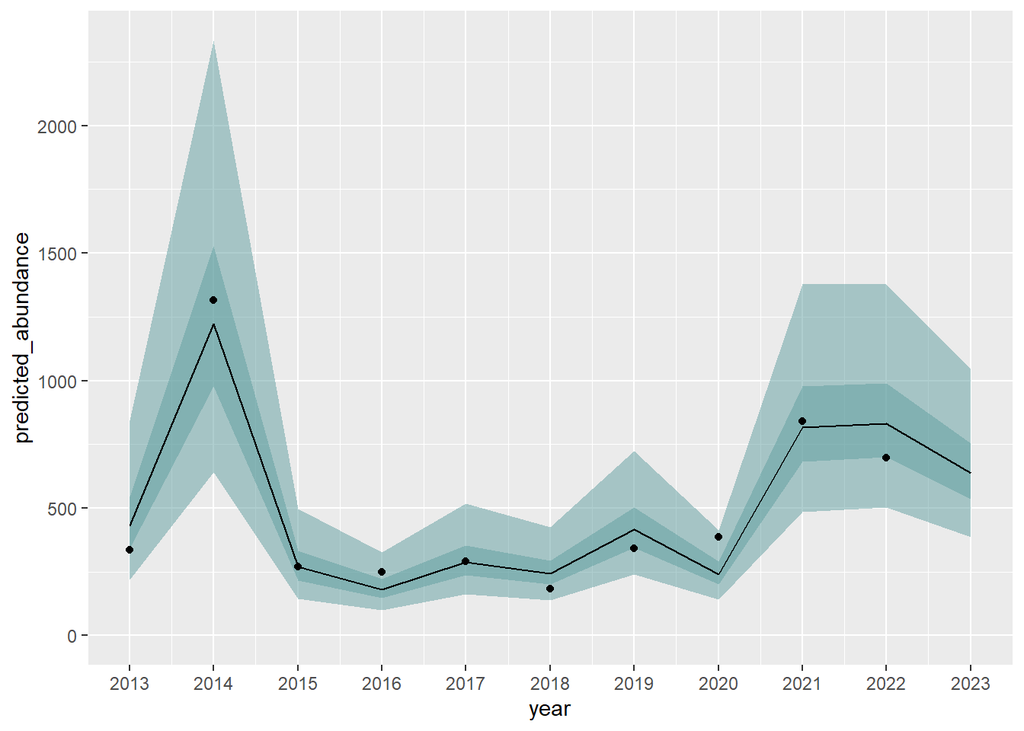

Figure 1. One-step-ahead predictions (black line) of total OPI coho abundance for the best model relative to observed abundance (black dots). Prediction intervals are shown as blue shading including 50% (dark), 95% (light)

```r
Figure1
```

Figure 2 shows the annual one-step-ahead predictions of abundance (lines) for the entire top model set (based on in-sample AIC) that was used in one step ahead evaluation and ensemble development relative to the observed abundance (black dots).

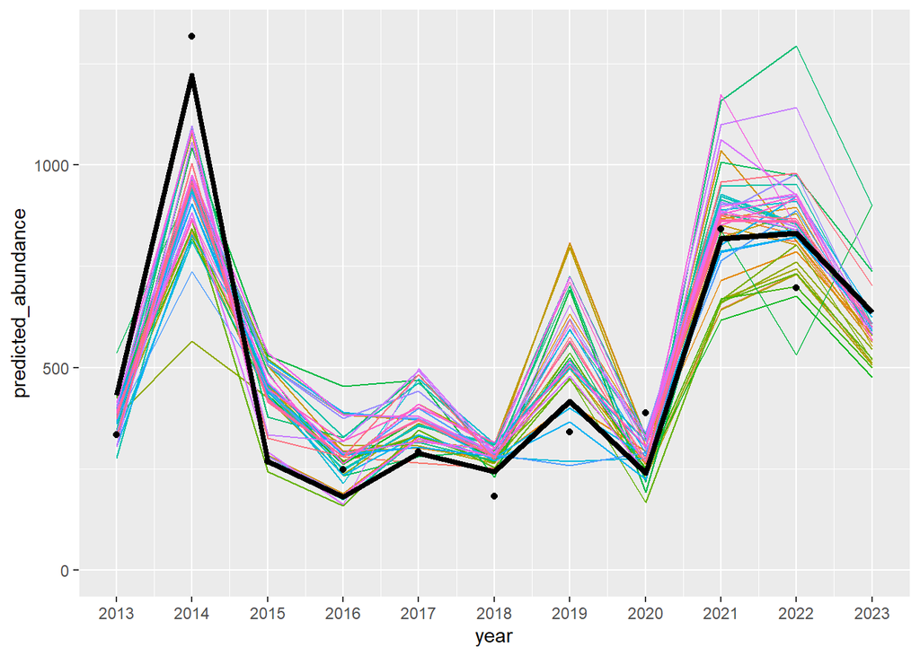

Figure 2. One-step-ahead predictions (lines) of total OPI coho abundance for the top model set relative to observed abundance (black dots).

```r
Figure2
```

## Appendix

Appendix 1 shows the raw data and covariates used in modeling.

```r
dat%>%
  dplyr::select(-period)%>%
  kbl(caption ="Appendix 1. data used for forecasting OPI Coho",digits =2)%>%
  kable_classic(full_width = F, html_font = "Cambria")
```

Appendix 1. data used for forecasting OPI Coho

| year | species | abundance | lag1_log_JackOPI | lag1_log_SmAdj | lag1_NPGO | lag1_PDO | WSST_A | PDO.MJJ | MEI.OND | UWI.JAS | SST.AMJ | SSH.AMJ | UWI.SON |
| --- | --- | --- | --- | --- | --- | --- | --- | --- | --- | --- | --- | --- | --- |
| 2000 | Coho | 673.1 | 3.55 | 0.51 | 1.52 | -1.38 | -0.21 | 0.78 | -1.32 | 51.00 | 10.67 | -103.47 | -34.18 |
| 2001 | Coho | 1478.7 | 4.47 | 0.28 | 1.89 | -0.78 | 0.09 | 0.35 | -0.73 | 35.78 | 11.36 | -46.77 | -26.83 |
| 2002 | Coho | 689.5 | 3.23 | 0.16 | 2.08 | -0.74 | -0.28 | -0.40 | -0.28 | 47.08 | 10.68 | -116.13 | -38.19 |
| 2003 | Coho | 1009.9 | 3.91 | 0.05 | 1.47 | -0.13 | 0.31 | -0.60 | 0.78 | 50.48 | 10.11 | -137.93 | -25.90 |
| 2004 | Coho | 693.6 | 3.57 | 0.29 | 0.96 | 0.53 | 0.28 | -0.17 | 0.28 | 55.48 | 11.08 | -52.07 | -26.35 |
| 2005 | Coho | 454.0 | 3.22 | 0.11 | 0.21 | -0.11 | -0.06 | 0.04 | 0.42 | 26.99 | 11.86 | -50.60 | 4.34 |
| 2006 | Coho | 523.4 | 3.25 | 0.06 | -1.47 | -0.09 | 0.37 | 0.52 | -0.73 | 51.75 | 12.54 | -13.00 | -9.01 |
| 2007 | Coho | 545.3 | 3.59 | 0.02 | -0.55 | -0.15 | -0.24 | 0.79 | 0.79 | 53.57 | 11.15 | -23.07 | -14.10 |
| 2008 | Coho | 576.9 | 2.78 | 0.08 | 0.58 | -0.46 | -0.62 | 0.64 | -1.14 | 27.52 | 10.62 | -109.77 | -9.88 |
| 2009 | Coho | 1051.0 | 4.10 | 0.20 | 1.49 | -1.33 | -0.77 | 0.16 | -1.08 | 32.71 | 9.62 | -98.67 | -10.66 |
| 2010 | Coho | 546.5 | 3.23 | 0.03 | 0.64 | -0.82 | -0.26 | -0.29 | 0.80 | 24.32 | 10.45 | -80.77 | -47.08 |
| 2011 | Coho | 454.2 | 3.15 | 0.05 | 1.29 | -0.74 | 0.11 | -0.50 | -2.11 | 34.21 | 11.68 | -32.63 | -32.89 |
| 2012 | Coho | 183.1 | 2.88 | 0.12 | 0.79 | -1.57 | -0.09 | -0.81 | -1.29 | 29.33 | 10.70 | -29.73 | -26.30 |
| 2013 | Coho | 335.1 | 3.27 | 0.19 | 1.42 | -1.41 | -0.05 | -0.74 | -0.14 | 53.55 | 11.02 | -17.30 | -29.90 |
| 2014 | Coho | 1316.5 | 3.94 | 0.13 | 0.36 | -0.93 | -0.38 | -0.76 | -0.17 | 35.30 | 10.66 | -88.80 | -7.81 |
| 2015 | Coho | 268.9 | 3.68 | 0.29 | -0.20 | 0.53 | 1.59 | -0.43 | 0.20 | 41.26 | 11.17 | -11.57 | -40.11 |
| 2016 | Coho | 247.7 | 2.98 | 0.21 | -1.38 | 0.80 | 0.92 | 0.19 | 2.00 | 40.41 | 10.28 | -97.97 | -7.85 |
| 2017 | Coho | 291.8 | 3.13 | 0.23 | -0.16 | 0.63 | 0.86 | 0.97 | -0.56 | 47.98 | 11.58 | -108.50 | -68.23 |
| 2018 | Coho | 182.8 | 2.95 | 0.12 | -0.86 | -0.06 | 0.41 | 1.28 | -0.63 | 46.09 | 11.19 | -49.77 | -36.18 |
| 2019 | Coho | 340.7 | 3.86 | 0.10 | -1.96 | -0.30 | 0.73 | 1.01 | 0.34 | 41.06 | 10.82 | -104.60 | -12.37 |
| 2020 | Coho | 387.7 | 2.72 | 0.03 | -2.28 | -0.03 | -0.08 | 0.89 | 0.36 | 20.07 | 10.47 | -86.57 | 4.07 |
| 2021 | Coho | 841.3 | 4.53 | 0.10 | -1.84 | -1.04 | 0.47 | 0.39 | -1.18 | 25.56 | 11.40 | -71.27 | -18.89 |
| 2022 | Coho | 696.0 | 4.15 | 0.07 | -0.91 | -1.57 | -0.13 | -0.09 | -1.44 | 40.84 | 10.97 | -123.17 | -64.07 |
| 2023 | Coho | NA | 3.97 | 0.07 | -1.31 | -1.77 | -0.04 | -0.60 | -1.64 | 33.83 | 11.47 | -90.30 | -6.61 |

Data Notes: 1) Jack OPI = Total Jack CR and Jack OC. 2) Jack CR = Columbia River jack returns corrected for small adults. 3) Jack OC = Oregon coastal and California hatchery jack returns corrected for small adults. 4) Total OPI = Columbia River (Sm D + Sm CR), Oregon coastal and Klamath Basin. 5) Sm CR = Columbia River smolt releases from the previous year expected to return as adults in the year listed. 6) Sm D = Columbia River delayed smolt releases from the previous year expected to return as adults in the year listed 7) SmAdj = JackCR*(Sm D/Sm CR) (this is a covariate used in the past OPI forecast)

GET THIS LIST OF COVARIATES USED FOR OREGON COAST NATURAL FORECAST: [DONE-ish] Multivariate ENSO Index (Oct-Dec; t-1) [DONE-ish] Spring Transition (Julian date; t-1) Upwelling (July-Sept; t-1) Upwelling (Sep-Nov; t-1) Sea Surface Temperature (Jan; t) Sea Surface Height (April-June; t-1) PDO (mean May-July; averaged over the 4-years prior to the return year)